# The Psychologist's data toolbox 2.0

### Matti Vuorre

Main | Introduction | R and RStudio | Import data to R | Questionnaire data | Multiple source files | [[source]](https://github.com/mvuorre/toolbox)

# Introduction to R and RStudio

Matti Vuorre

2016-04-01

# 1 Introduction

The most basic tools in our toolbox are the programming language, [**R**](https://www.r-project.org/) (R Core Team, 2015); and its associated user interface, [**RStudio**](https://www.rstudio.com/) (RStudio Team, 2015). We prefer these tools over alternatives, such as SPSS, Excel, or MATLAB because they are **free**.

# 2

R is a programming language that was developed some decades ago by a bunch of statisticians in New Zealand. Because it was developed by statisticians, it is very suitable for *statistical programming* but is also hated by programmers. We can think of a programming language, such as R, as something that lives on our computer, and when requested, performs computation on the input given to it. In order to give input to R, we need to open a *console*, that allows us to type inputs to R. The same console also prints the outputs of the computations performed on our inputs. Pictured below is the R console, where I’ve asked R to *get* the Working Directory. I then also checked if math still works.

[figure not shown]

# 3

RStudio is an *Integrated Development Environment* for the R language. Within RStudio, we can access the R console, and more. In addition to the R console, RStudio provides a **source** panel, an **environment** panel, and a **viewer** panel. Each of these panels are shown in RStudio’s default view below:

[figure not shown]

## 3.1 Get started with RStudio

Go ahead and open RStudio on your computer. You will see a four-panel layout similar to what I’ve shown above.

The two panels on the left, that I choose to display with a black background for my aesthetic preferences, are your main “blackboard”: You write commands in the **source** panel on the top, and view output in the **console** below. The crucial difference between these two panels is that if you type commands directly into the console, R evaluates the command but doesn’t save the command itself. The source panel is simply a fancy text editor that allows you to type code just as you would in a text editor, but also allows you to execute the code, the results of which are then displayed in the console below.

The two panels on the right are for maintaining the working environment, displaying plots, and doing all sorts of other miscellaneous neat things. The upper right panel displays the **environment** that will be populated with objects in your workspace. If you, for example, save a value into a variable, the variable will be displayed here.

The bottom right panel displays plots, can be used to browse files, manage packages, and view help pages. Now, we will use this panel, specifically its **Files** tab, to set the working directory. Open the Files tab, and navigate to the root of the folder you downloaded in the introduction chapter (`toolbox/`). Then set this folder as your working directory by clicking the “More” button in the Files tab.

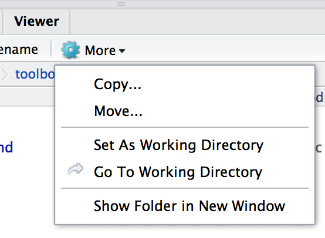

R now understands that any command you type in that refers to outside files should refer to files within this directory. For instance, we can use R to access the file `LICENSE.md` (don’t worry about the command, but appreciate that R can access this file and print its contents):

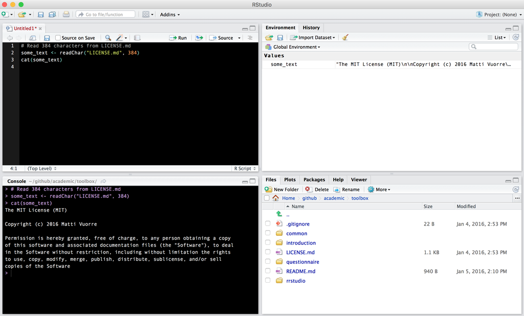

As you can see from the image, I entered some code in the **Source** panel, and executed each line by pressing `Cmd + Enter`. The results of executing these lines then appeared in the **Console**: We read 384 characters from the file `LICENSE.md` into an object (`some_text`). This object was subsequently created in the environment, and is therefore visible in the **Environment** panel. We then printed the object in the console. The **Files** panel displays the contents of the working directory.

Equipped with this basic knowledge of R and RStudio, we can begin our first task: Installing additional R packages.

## 3.2 Install packages

As I explained in the introduction, we will rely on additional packages to the R programming language. Additional packages are user-contributed “modules” containing multiple functions that make using R easier, and prevent us from having to re-invent the wheel. Installing these packages is simple; you only need to call a few functions in R. So, with R open, enter the following commands to the console:

```r
install.packages("readr")
install.packages("dplyr")
install.packages("ggplot2")
install.packages("reshape2")
```

These commands connect to the online [R package repository](https://cran.r-project.org/) and download and install the packages specified by the text strings. Specifically, we installed four packages that we will be using in our data-wrangling workflow.

- **readr** (Wickham & Francois, 2015b)
  - Reading data tables with *style*
- **dplyr** (Wickham & Francois, 2015a)
  - comprehensive framework for a data-wrangling pipeline
- **ggplot2** (Wickham, 2009)
  - grammar of graphics plotting framework
- **reshape2** (Wickham, 2007)
  - transforms data between long and wide formats

## 3.3 Figure 1

R is pre-installed with easy-to-access plotting functions. To illustrate how easy it is to perform plotting in R, we create Figure 1 (again, don’t worry about the code just yet):

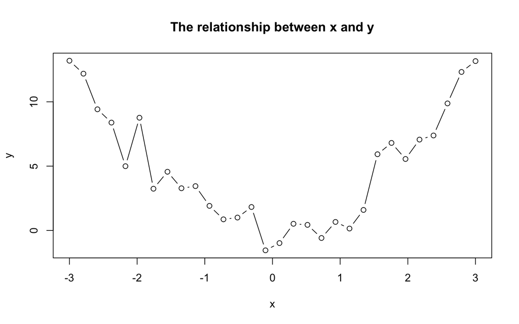

```r
n <- 30
x <- seq(-3, 3, length = n)
y <- x^2 * 1.5 + rnorm(n)
plot(x, y, main = "The relationship between x and y", type = "b")
```

Cool, right?!

You are now ready to begin exploring any of the data wrangling scenarios in [The psychologist’s data toolbox 2.0](https://github.com/mvuorre/toolbox).

# 4 Further reading

Although there are many excellent books on using R, I’ve found online courses and websites more helpful than books.

## 4.2 Websites

The Institute for Digital Research and Education at UCLA maintains a brilliant [website](http://www.ats.ucla.edu/stat/r/) with tons of R-related material.

## 4.3 Specific topics

The two best ways to get answers to specific questions about R are 1. [using a search engine](http://lmgtfy.com/?q=how+to+use+R), and 2. viewing and posting questions to [Stack Overflow](http://stackoverflow.com/questions/tagged/r).

# References

R Core Team. (2015). *R: A language and environment for statistical computing*. Vienna, Austria: R Foundation for Statistical Computing. Retrieved from https://www.R-project.org/

RStudio Team. (2015). *RStudio: Integrated development environment for r*. Boston, MA: RStudio, Inc. Retrieved from http://www.rstudio.com/

Wickham, H. (2007). Reshaping data with the reshape package. *Journal of Statistical Software*, *21*(12), 1–20. Retrieved from http://www.jstatsoft.org/v21/i12/

Wickham, H. (2009). *Ggplot2: Elegant graphics for data analysis*. Springer-Verlag New York. Retrieved from http://had.co.nz/ggplot2/book

Wickham, H., & Francois, R. (2015a). *Dplyr: A grammar of data manipulation*. Retrieved from http://CRAN.R-project.org/package=dplyr

Wickham, H., & Francois, R. (2015b). *Readr: Read tabular data*. Retrieved from http://CRAN.R-project.org/package=readr